# PHW251 – Milestone 4

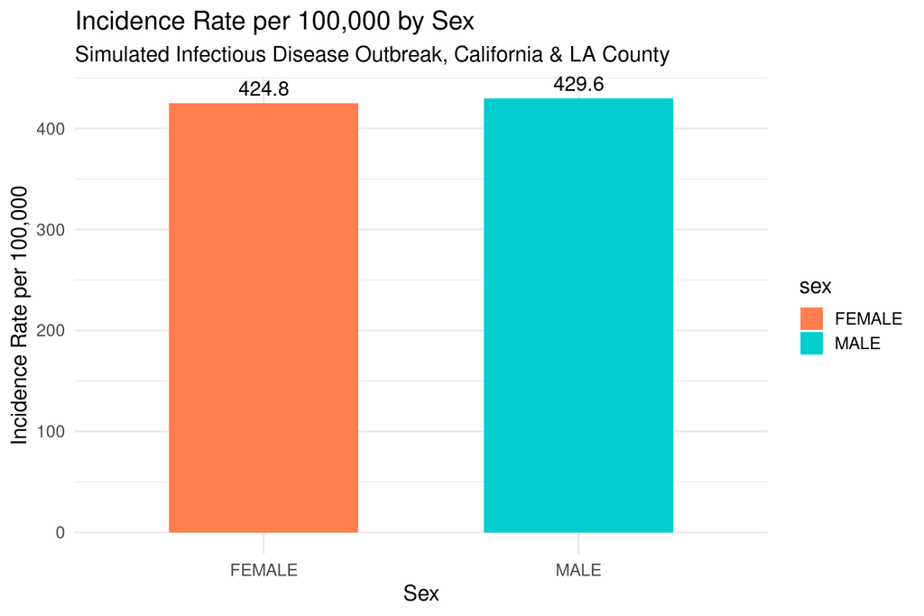

```r
ggplot(sex_summary,
       aes(x = sex, y = incidence_rate_100k, fill = sex)) +
  geom_col(width = 0.6) +
  geom_text(aes(label = round(incidence_rate_100k, 1)),
            vjust = -0.5, size = 5) +
  scale_fill_manual(values = c("FEMALE" = "coral", "MALE" = "cyan3")) +
  labs(
    title = "Incidence Rate per 100,000 by Sex",
    subtitle = "Simulated Infectious Disease Outbreak, California & LA County",
    x = "Sex",
    y = "Incidence Rate per 100,000"
  ) +
  theme_minimal(base_size = 15)
```

Incidence rates were nearly identical between males and females, suggesting no major sex-based differences in infection risk during this outbreak.

```r
library(gt)

sex_summary %>%
  gt() %>%
  tab_header(
    title = "Incidence Rate per 100,000 by Sex",
    subtitle = "Simulated Infectious Disease Outbreak, California & LA County"
  ) %>%
  fmt_number(
    columns = c(total_cases, total_population, incidence_rate_100k),
    decimals = 1
  )
```

Incidence Rate per 100,000 by Sex

Simulated Infectious Disease Outbreak, California & LA County

| sex | total_cases | total_population | incidence_rate_100k |
| --- | --- | --- | --- |
| FEMALE | 2,294,166.0 | 540,075,676.0 | 424.8 |
| MALE | 2,255,417.0 | 525,013,644.0 | 429.6 |

The total number of cases and overall incidence rate are similar for males and females, indicating that sex did not meaningfully influence the burden of disease in this population.

```r
age_summary <- joined_data_ca %>%
  group_by(age_group) %>%
  summarise(
    total_cases = sum(cases_new, na.rm = TRUE),
    total_population = sum(population, na.rm = TRUE),
    incidence_rate_100k = (total_cases / total_population) * 100000
  )
```

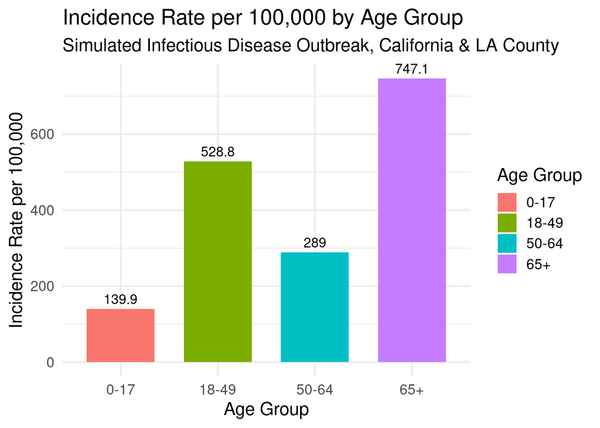

```r
ggplot(age_summary,
       aes(x = age_group, y = incidence_rate_100k, fill = age_group)) +
  geom_col(width = 0.7) +
  geom_text(aes(label = round(incidence_rate_100k, 1)),
            vjust = -0.5, size = 4) +
  labs(
    title = "Incidence Rate per 100,000 by Age Group",
    subtitle = "Simulated Infectious Disease Outbreak, California & LA County",
    x = "Age Group",
    y = "Incidence Rate per 100,000",
    fill = "Age Group"
  ) +
  theme_minimal(base_size = 15)
```

[figure not shown]

```r
race_summary <- joined_data_ca %>%
  group_by(race) %>%
  summarise(
    total_cases = sum(cases_new, na.rm = TRUE),
    total_population = sum(population, na.rm = TRUE),
    incidence_rate_100k = (total_cases / total_population) * 100000
  ) %>%
  arrange(desc(incidence_rate_100k))

ggplot(race_summary,
       aes(x = reorder(race, incidence_rate_100k),
           y = incidence_rate_100k,
           fill = race)) +
  geom_col(width = 0.7) +
  geom_text(aes(label = round(incidence_rate_100k, 1)),
            vjust = -0.5, size = 3.8) +
  labs(
    title = "Incidence Rate per 100,000 by Race/Ethnicity",
    subtitle = "Simulated Infectious Disease Outbreak, California & LA County",
    x = "Race/Ethnicity",
    y = "Incidence Rate per 100,000",
    fill = "Race/Ethnicity"
  ) +
  theme_minimal(base_size = 14) +
  theme(axis.text.x = element_text(angle = 25, hjust = 1))
```

Incidence rates varied widely across racial and ethnic groups, indicating potential differences in exposure, underlying health status, or access to testing and care.

## Additional

Incidence rates were comparable across sex, with only a very small difference between females and males. This suggests that transmission and overall disease burden were distributed fairly evenly across both groups during this outbreak. These patterns indicate that sex alone may not be a major driver of risk in this dataset, and other factors such as age, race or exposure patterns may be more influential.

## Discussion

Overall, the incidence trends show that sex does not appear to meaningfully influence infection risk in this outbreak, as the rates between males and females are nearly identical. This consistency suggests broad and similar exposure patterns across both groups. These descriptive findings help build a high-level understanding of the outbreak before moving into more advanced or stratified analyses, and they highlight the importance of evaluating additional demographic or structural factors that may better explain differences in disease burden.